# STUDENT PERFORMANCE AND BEHAVIOR ANALYSIS

Anasah Wawem Christopher  
2025-04-12

## Introduction

This project focuses on analyzing students’ academic performance by examining the various factors that influence it, including their background, behavior, study habits, lifestyle, and overall health. By exploring the interplay between these elements, the study aims to uncover meaningful insights into how different aspects of a student’s life can impact their educational outcomes. To achieve this, a range of statistical techniques were employed, such as Analysis of Variance (ANOVA), Regression Analysis, Hypothesis Testing, and Data Visualization. These methods provided a comprehensive understanding of the patterns and relationships within the data, helping to draw informed conclusions and support decision-making in educational settings.

## Data Description

This is student performance and behavior data set from kaggle.com. This dataset is real data of 5,000 records collected from a private learning provider. The dataset includes 23 attributes tabulated below.

| Column Name | Data Type | Description |
| --- | --- | --- |
| `Student_ID` | String | Unique identifier for each student |
| `First_Name` | String | Student’s first name |
| `Last_Name` | String | Student’s last name |
| `Email` | String | Contact email (can be anonymized) |
| `Gender` | Categorical | Male, Female, Other |
| `Age` | Integer | Age of the student |
| `Department` | String | Student’s department (e.g., CS, Engineering, Business) |
| `Attendance (%)` | Float | Attendance percentage (0-100%) |
| `Midterm_Score` | Float | Midterm exam score (out of 100) |
| `Final_Score` | Float | Final exam score (out of 100) |
| `Assignments_Avg` | Float | Average score of all assignments (out of 100) |
| `Quizzes_Avg` | Float | Average quiz scores (out of 100) |
| `Participation_Score` | Float | Score based on class participation (0-10) |
| `Projects_Score` | Float | Project evaluation score (out of 100) |
| `Total_Score` | Float | Weighted sum of all grades |
| `Grade` | Categorical | Letter grade (A, B, C, D, F) |
| `Study_Hours_per_Week` | Float | Average study hours per week |
| `Extracurricular_Activities` | Boolean | Whether the student participates in extracurriculars (Yes/No) |
| `Internet_Access_at_Home` | Boolean | Does the student have access to the internet at home? (Yes/No) |
| `Parent_Education_level` | Categorical | Highest education level of parents (None, High School, Bachelor’s, Master’s, PhD) |
| `Family_Income_Level` | Categorical | Low, Medium, High |
| `Stress_Level (1-10)` | Integer | Self-reported stress level (1: Low, 10: High) |
| `Sleep_Hours_per_Night` | Float | Average hours of sleep per night |

## Data Processing

```r
#packages
library(tidyr)
library(ggplot2)
library(ggpubr)
library(corrplot)
library(fitdistrplus)
library(misty)
library(mvnmle)
library(mice)
library(reshape2)
library(car)
suppressPackageStartupMessages(library(pROC))


Data=read.csv("C:/Users/Mrnotebook/Desktop/Data set/Students_Grading_Dataset.csv",na.strings = c("", "Na", "na"))

options(width = 200)
```

```r
#Renaming Columns
names(Data)[names(Data) == "Attendance...."] = "Attendance_Percent"
names(Data)[names(Data) == "Stress_Level..1.10."] = "Stress_Level"
```

```r
#Checking for missing data

colSums(is.na(Data))
```

```
##                 Student_ID                 First_Name                  Last_Name                      Email                     Gender                        Age                 Department
##                          0                          0                          0                          0                          0                          0                          0
##         Attendance_Percent              Midterm_Score                Final_Score            Assignments_Avg                Quizzes_Avg        Participation_Score             Projects_Score
##                        516                          0                          0                        517                          0                          0                          0
##                Total_Score                      Grade       Study_Hours_per_Week Extracurricular_Activities    Internet_Access_at_Home     Parent_Education_Level        Family_Income_Level
##                          0                          0                          0                          0                          0                        984                          0
##               Stress_Level      Sleep_Hours_per_Night
##                          0                          0
```

```r
head(Data)
```

```
##   Student_ID First_Name Last_Name                   Email Gender Age  Department Attendance_Percent Midterm_Score Final_Score Assignments_Avg Quizzes_Avg Participation_Score Projects_Score
## 1      S1000       Omar  Williams student0@university.com Female  22 Engineering              52.29         55.03       57.82           84.22       74.06                3.99          85.90
## 2      S1001      Maria     Brown student1@university.com   Male  18 Engineering              97.27         97.23       45.80              NA       94.24                8.32          55.65
## 3      S1002      Ahmed     Jones student2@university.com   Male  24    Business              57.19         67.05       93.68           67.70       85.70                5.05          73.79
## 4      S1003       Omar  Williams student3@university.com Female  24 Mathematics              95.15         47.79       80.63           66.06       93.51                6.54          92.12
## 5      S1004       John     Smith student4@university.com Female  23          CS              54.18         46.59       78.89           96.85       83.70                5.97          68.42
## 6      S1005       Liam     Brown student5@university.com   Male  21 Engineering                 NA         78.85       43.53           71.40       52.20                6.38          67.29
##   Total_Score Grade Study_Hours_per_Week Extracurricular_Activities Internet_Access_at_Home Parent_Education_Level Family_Income_Level Stress_Level Sleep_Hours_per_Night
## 1       56.09     F                  6.2                         No                     Yes            High School              Medium            5                   4.7
## 2       50.64     A                 19.0                         No                     Yes                   None              Medium            4                   9.0
## 3       70.30     D                 20.7                         No                     Yes               Master's                 Low            6                   6.2
## 4       61.63     A                 24.8                        Yes                     Yes            High School                High            3                   6.7
## 5       66.13     F                 15.4                        Yes                     Yes            High School                High            2                   7.1
## 6       62.08     B                  8.5                        Yes                     Yes                    PhD                High            1                   5.0
```

**Little’s Missing Completely at Random (MCAR) Test**

```r
na.test(data=Data)
```

[output not shown]

The p-vallue is greater than alpha This suggests that missing values are likely MCAR (Missing Completely at Random). There is no strong evidence that missingness depends on observed or unobserved data. The missing rows consist of 35.4% of the total records of 5,0000 hence imputation method is recommended.

```r
#Computing missing values for numeric variables
Data$Attendance_Percent[is.na(Data$Attendance_Percent)] = mean(Data$Attendance_Percent, na.rm = TRUE)

Data$Assignments_Avg[is.na(Data$Assignments_Avg)] = mean(Data$Assignments_Avg, na.rm = TRUE)
colnames(Data)
```

```
##  [1] "Student_ID"                 "First_Name"                 "Last_Name"                  "Email"                      "Gender"                     "Age"
##  [7] "Department"                 "Attendance_Percent"         "Midterm_Score"              "Final_Score"                "Assignments_Avg"            "Quizzes_Avg"
## [13] "Participation_Score"        "Projects_Score"             "Total_Score"                "Grade"                      "Study_Hours_per_Week"       "Extracurricular_Activities"
## [19] "Internet_Access_at_Home"    "Parent_Education_Level"     "Family_Income_Level"        "Stress_Level"               "Sleep_Hours_per_Night"
```

```r
#Computing missing values for categorical variables


Data$Parent_Education_Level=ordered( Data$Parent_Education_Level,
  levels = c("None", "High School", "Bachelor's", "Master's", "PhD"))

methods = rep("", ncol(Data))
names(methods) = colnames(Data)
methods["Parent_Education_Level"] = "polr"

imputed_data=mice(Data, method = methods, m = 5, maxit = 10,print = FALSE)
complete_data=complete(imputed_data, 1)
Data=complete_data
```

For numeric varibles, mean approach was used to find the missing values. Multiple Imputation (Gold Standard) specifically proportional odds model (polr) was used on categorical(ordinal) variable to keep the ordering meaningful.

```r
#Verification of missing values
colSums(is.na(Data))
```

```
##                 Student_ID                 First_Name                  Last_Name                      Email                     Gender                        Age                 Department
##                          0                          0                          0                          0                          0                          0                          0
##         Attendance_Percent              Midterm_Score                Final_Score            Assignments_Avg                Quizzes_Avg        Participation_Score             Projects_Score
##                          0                          0                          0                          0                          0                          0                          0
##                Total_Score                      Grade       Study_Hours_per_Week Extracurricular_Activities    Internet_Access_at_Home     Parent_Education_Level        Family_Income_Level
##                          0                          0                          0                          0                          0                          0                          0
##               Stress_Level      Sleep_Hours_per_Night
##                          0                          0
```

```r
unique(Data$Parent_Education_Level)
```

```
## [1] High School None        Master's    PhD         Bachelor's
## Levels: None < High School < Bachelor's < Master's < PhD
```

## Summary Statistics

```r
#Numeric variables
variables=c("Age", "Attendance_Percent", "Midterm_Score", "Final_Score", "Assignments_Avg", "Quizzes_Avg", "Projects_Score","Total_Score","Study_Hours_per_Week", "Sleep_Hours_per_Night")

lapply(Data[variables], summary)
```

```
## $Age
##    Min. 1st Qu.  Median    Mean 3rd Qu.    Max.
##   18.00   19.00   21.00   21.05   23.00   24.00
##
## $Attendance_Percent
##    Min. 1st Qu.  Median    Mean 3rd Qu.    Max.
##   50.01   64.74   75.43   75.43   86.18  100.00
##
## $Midterm_Score
##    Min. 1st Qu.  Median    Mean 3rd Qu.    Max.
##   40.00   55.46   70.51   70.33   84.97   99.98
##
## $Final_Score
##    Min. 1st Qu.  Median    Mean 3rd Qu.    Max.
##   40.00   54.67   69.73   69.64   84.50   99.98
##
## $Assignments_Avg
##    Min. 1st Qu.  Median    Mean 3rd Qu.    Max.
##   50.00   63.69   74.80   74.80   85.57   99.98
##
## $Quizzes_Avg
##    Min. 1st Qu.  Median    Mean 3rd Qu.    Max.
##   50.03   62.49   74.69   74.91   87.63   99.96
##
## $Projects_Score
##    Min. 1st Qu.  Median    Mean 3rd Qu.    Max.
##   50.01   62.32   74.98   74.92   87.37  100.00
##
## $Total_Score
##    Min. 1st Qu.  Median    Mean 3rd Qu.    Max.
##   50.02   62.84   75.39   75.12   87.65   99.99
##
## $Study_Hours_per_Week
##    Min. 1st Qu.  Median    Mean 3rd Qu.    Max.
##    5.00   11.40   17.50   17.66   24.10   30.00
##
## $Sleep_Hours_per_Night
##    Min. 1st Qu.  Median    Mean 3rd Qu.    Max.
##   4.000   5.200   6.500   6.488   7.700   9.000
```

From the summary statistics, mean and median of all numeric variables are either same or very close and this suggests symmetric distribution or nearly symmetric. Students’ scores in Attendance, Assignment, Quizzes, Projects, and Total have a minimum around 50 and maximum around 100. The minimum midterm and final scores are same, likewise the maximum score.

## Visualizations

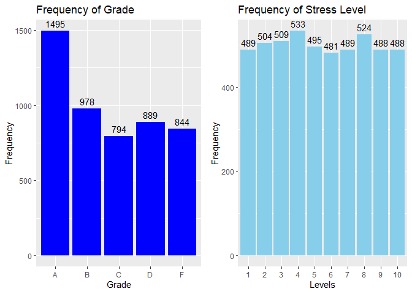

```r
freq_table = as.data.frame(table(Data$Stress_Level))
colnames(freq_table)=c("Category", "Frequency")


plotP=ggplot(freq_table, aes(x = Category, y = Frequency)) +
  geom_bar(stat = "identity", fill = "skyblue") +
  geom_text(aes(label = Frequency), vjust = -0.5) +
  labs(x = "Levels", y = "Frequency", title = "Frequency of Stress Level")

freq_table1 = as.data.frame(table(Data$Grade))
colnames(freq_table1)=c("Category", "Frequency")


plotG=ggplot(freq_table1, aes(x = Category, y = Frequency)) +
   geom_bar(stat = "identity", fill = "blue") +
   geom_text(aes(label = Frequency), vjust = -0.5) +
   labs(x = "Grade", y = "Frequency", title = "Frequency of Grade")

 annotate_figure(ggarrange(plotG, plotP))
```

The most obtained grade is A and the least obtained grade is C. If grade C is used as a pass grade, then students’ performance here is very good but if a better grade like B is a pass grade, then this is a poor performance.  
Students report a wide range of stress levels, with no extreme concentration in one category. The most frequently reported stress level is 4, chosen by 533 students suggesting a moderate level of stress is most common. Even the highest stress level (10) and the lowest (1) are reported by nearly 490 students each, indicating that stress experiences vary significantly across the student population.

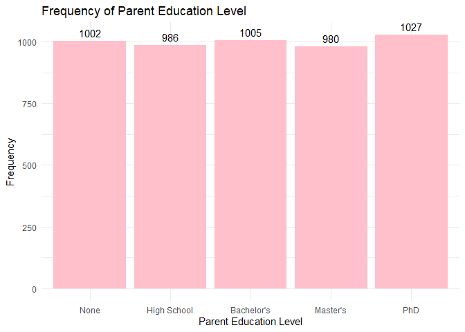

```r
freq_table2 = as.data.frame(table(Data$Parent_Education_Level))
colnames(freq_table2)=c("Category", "Frequency")


ggplot(freq_table2, aes(x = Category, y = Frequency)) +
  geom_bar(stat = "identity", fill = "pink") +
  geom_text(aes(label = Frequency), vjust = -0.5) +
  labs(x = "Parent Education Level", y = "Frequency", title = "Frequency of Parent Education Level")+
  theme_minimal()
```

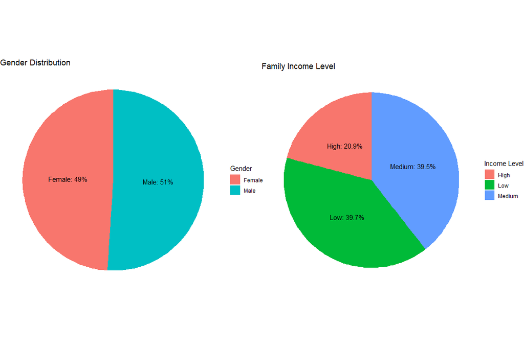

```r
gender_counts = as.data.frame(table(Data$Gender))
colnames(gender_counts) = c("Gender", "Count")

gender_counts$Percent = gender_counts$Count / sum(gender_counts$Count) * 100

gender_counts$Label = paste0(gender_counts$Gender, ": ", round(gender_counts$Percent, 1), "%")

plotG = ggplot(gender_counts, aes(x = "", y = Count, fill = Gender)) +
  geom_bar(stat = "identity", width = 1) +
  coord_polar(theta = "y") +
  labs(title = "Gender Distribution") +
  theme_void() +
  geom_text(aes(label = Label), position = position_stack(vjust = 0.5))


IncomeLevel_counts = as.data.frame(table(Data$Family_Income_Level))
colnames(IncomeLevel_counts) = c("Income_Level", "Count")


IncomeLevel_counts$Percent = IncomeLevel_counts$Count / sum(IncomeLevel_counts$Count) * 100

IncomeLevel_counts$Label = paste0(IncomeLevel_counts$Income_Level, ": ",
                                   round(IncomeLevel_counts$Percent, 1), "%")

plotI = ggplot(IncomeLevel_counts, aes(x = "", y = Count, fill = Income_Level)) +
  geom_bar(stat = "identity", width = 1) +
  coord_polar(theta = "y") +
  labs(title = "Family Income Level", fill = "Income Level") +
  theme_void() +
  geom_text(aes(label = Label), position = position_stack(vjust = 0.5))


annotate_figure(ggarrange(plotG, plotI))
```

There are slightly many male (51%) students than female (49%) students. Most students come from family of Low or Medium income level. Students from family of high income level are not many as low and medium.

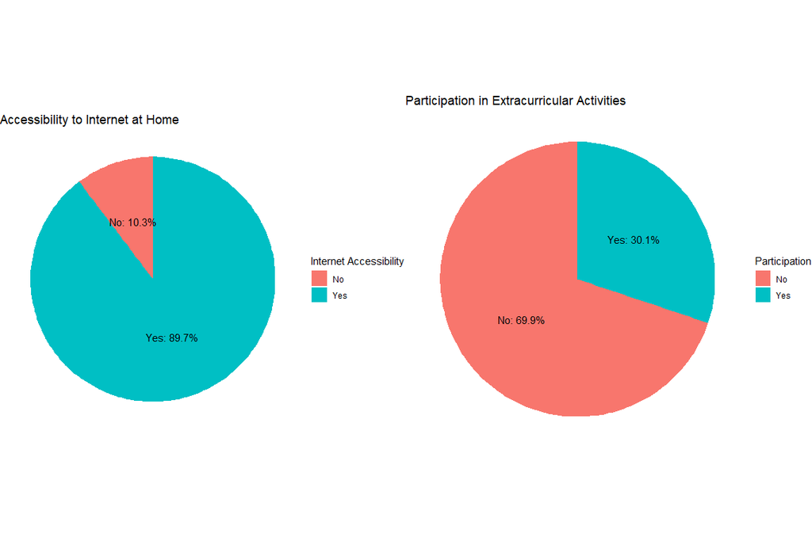

```r
Access_counts = as.data.frame(table(Data$Internet_Access_at_Home))
colnames(Access_counts) = c("Internet_Accessibility", "Count")

Access_counts$Percent = Access_counts$Count / sum(Access_counts$Count) * 100

Access_counts$Label=paste0(Access_counts$Internet_Accessibility, ": ",
                              round(Access_counts$Percent, 1), "%")


plot1 = ggplot(Access_counts, aes(x = "", y = Count, fill = Internet_Accessibility)) +
  geom_bar(stat = "identity", width = 1) +
  coord_polar(theta = "y") +
  labs(title = "Accessibility to Internet at Home", fill= "Internet Accessibility") +
  theme_void() +
  geom_text(aes(label = Label), position = position_stack(vjust = 0.5))




Activity_counts = as.data.frame(table(Data$Extracurricular_Activities))
colnames(Activity_counts) = c("Extracurricular_Activities", "Count")

Activity_counts$Percent = Activity_counts$Count / sum(Activity_counts$Count) * 100

Activity_counts$Label = paste0(Activity_counts$Extracurricular_Activities, ": ",
                                round(Activity_counts$Percent, 1), "%")


plot2 = ggplot(Activity_counts, aes(x = "", y = Count, fill = Extracurricular_Activities)) +
  geom_bar(stat = "identity", width = 1) +
  coord_polar(theta = "y") +
  labs(title = "Participation in Extracurricular Activities", fill="Participation") +
  theme_void() +
  geom_text(aes(label = Label), position = position_stack(vjust = 0.5))


 annotate_figure(ggarrange(plot1, plot2))
```

Out of 5,000 students, only 515 (10.3%) students do not have access to internet at home. This factor is likely to have impact on their academic performance.

Less than half of the students (30.1%) involves themselves in extracurricular activities.This can also have impact on their performance. This will be confirmed from the hypothesis testing

## Distributions

**Testing for normality of all continuous variables at 5% significant level**

$H_0$ The data in variable $i$ are normally distributed.

$H_1$ The data in variable $i$ are not normally distributed.

```r
sapply(Data[variables], function(x) shapiro.test(x)$p.value)
```

```
##                   Age    Attendance_Percent         Midterm_Score           Final_Score       Assignments_Avg           Quizzes_Avg        Projects_Score           Total_Score  Study_Hours_per_Week
##          1.081041e-45          5.851692e-32          4.373614e-36          1.113420e-36          1.558766e-32          6.011164e-37          5.904634e-37          1.737246e-36          1.653131e-37
## Sleep_Hours_per_Night
##          3.985749e-37
```

All the p-values for the numeric variables are less than alpha, hence none of the variables follows normal distribution.

*Distribution and Distribution Fitting of Total Score*

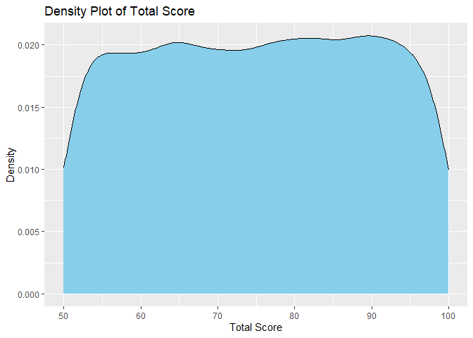

```r
ggplot(Data, aes(x = Total_Score)) +
  geom_density(fill = "skyblue", alpha = 1) +
  labs(title = "Density Plot of Total Score", x = "Total Score", y = "Density")
```

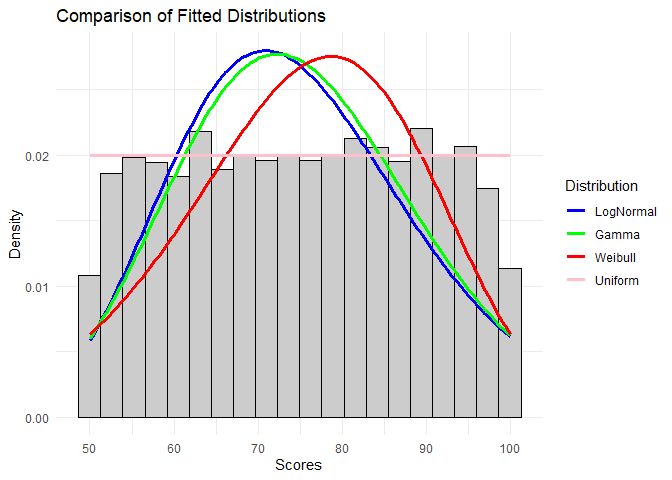

```r
# Fitting the distributions
fit_lognorm = fitdist(Data$Total_Score, "lnorm")
fit_gamma = fitdist(Data$Total_Score, "gamma")
fit_weibull = fitdist(Data$Total_Score, "weibull")
fit_unif = list(min = min(Data$Total_Score), max = max(Data$Total_Score))

x_vals = seq(min(Data$Total_Score), max(Data$Total_Score), length.out = 100)


densities = data.frame(
  x = x_vals,
  LogNormal = dlnorm(x_vals, fit_lognorm$estimate["meanlog"], fit_lognorm$estimate["sdlog"]),
  Gamma = dgamma(x_vals, fit_gamma$estimate["shape"], fit_gamma$estimate["rate"]),
  Weibull = dweibull(x_vals, fit_weibull$estimate["shape"], fit_weibull$estimate["scale"]),
  Uniform = dunif(x_vals, min = fit_unif$min, max = fit_unif$max)
)


densities_long = melt(densities, id.vars = "x", variable.name = "Distribution", value.name = "Density")


ggplot() +
  geom_histogram(aes(x = Data$Total_Score, y = after_stat(density)), bins = 20, fill = "gray80", color = "black") +
  geom_line(data = densities_long, aes(x = x, y = Density, color = Distribution), linewidth = 1.2) +
  labs(title = "Comparison of Fitted Distributions",
       x = "Scores", y = "Density") +
  theme_minimal() +
  scale_color_manual(values = c("LogNormal" = "blue", "Gamma" = "green", "Weibull" = "red", "Uniform" = "pink"))
```

```r
#Kolmogorov Smirnov test for distribution fit
ks.test(Data$Total_Score, "punif", min = fit_unif$min, max = fit_unif$max)
```

[output not shown]

The density curve is almost flat across the range from around 50 to 100 suggesting that total scores are uniformly distributed in that range.Students are almost equally distributed across a wide range of scores.  
From further analysis, both visual and goodness of fit test confirms that the total score fit well with a uniform distribution. There is sharp drops at the both ends indicating that few students had scores around 50 and 100 as compared to scores between this range. The distribution shows some kind of balance assessment or randomness of the score.

*Distribution of Age*

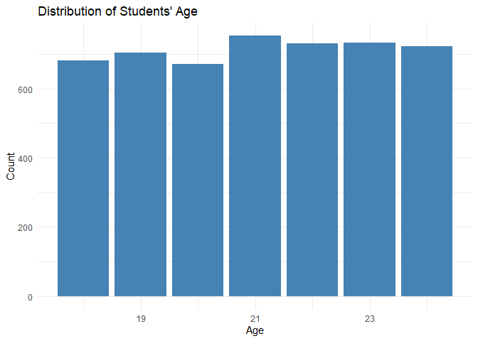

```r
ggplot(Data, aes(x = Age)) +
  geom_bar(fill = "steelblue") +
  labs(title = "Distribution of Students' Age",
       x = "Age",
       y = "Count") +
  theme_minimal()
```

*Distribution of Students in Departments*

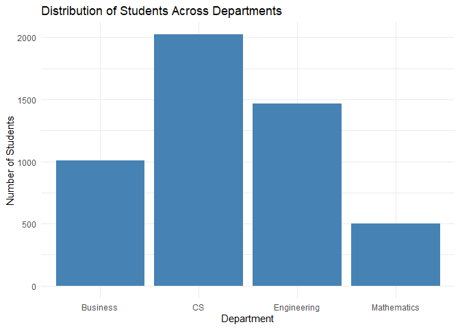

```r
ggplot(Data, aes(x = Department)) +
  geom_bar(fill = "steelblue") +
  labs(title = "Distribution of Students Across Departments",
       x = "Department",
       y = "Number of Students") +
  theme_minimal()
```

There are 4 departments with unequal number of students in each. Computer Science (CS) department has the highest students followed by Engineering, Business and Mathematics department having the least number of students.

## Hypothesis Testing

**Test for association between student’s grade and access to internet. Significant level of 5%.**

$H_0:$ Student grade is independent on internet accessibility at home

$H_1:$ Student grade is dependent on internet accessibility at home

```r
Contingency1=table(Data$Grade, Data$Internet_Access_at_Home)
Contingency1
```

```
##
##       No  Yes
##   A  154 1341
##   B  109  869
##   C   79  715
##   D   84  805
##   F   89  755
```

```r
chisq.test(Contingency1)
```

```
##
##  Pearson's Chi-squared test
##
## data:  Contingency1
## X-squared = 1.6137, df = 4, p-value = 0.8063
```

We fail to reject the null hypothesis since p-value is greater than the significant level. The accessibility to internet at home does not have any impact on the student’s grade.

**Test for association between student’s grade and involvement in extracurricular activities at 5% significant level.**

$H_0:$ Student grade is independent on their participation in extracurricular activities

$H_1:$ Student grade is dependent on their participation in extracurricular activities

```r
Contingency2=table(Data$Grade, Data$Extracurricular_Activities)
Contingency2
```

```
##
##       No  Yes
##   A 1068  427
##   B  670  308
##   C  556  238
##   D  595  294
##   F  604  240
```

```r
chisq.test(Contingency2)
```

```
##
##  Pearson's Chi-squared test
##
## data:  Contingency2
## X-squared = 7.4193, df = 4, p-value = 0.1153
```

We fail to reject the null hypothesis since there is insufficient evidence, suggesting that a student’s grade does not depend on whether he or she participates in extracurricular activities.

**Test for association between student’s grade and family income level at 5% significant level.**

$H_0:$ Student grade is independent on their family income level

$H_1:$ Student grade is dependent on their family income level

```r
Contingency3=table(Data$Grade, Data$Family_Income_Level)
Contingency3
```

```
##
##     High Low Medium
##   A  305 598    592
##   B  207 374    397
##   C  183 309    302
##   D  182 361    346
##   F  167 341    336
```

```r
chisq.test(Contingency3)
```

```
##
##  Pearson's Chi-squared test
##
## data:  Contingency3
## X-squared = 4.3382, df = 8, p-value = 0.8254
```

There is insufficient evidence to conclude that students’ grade depends on their family income level. This is because the p-value is greater than the significant level.

**Test for association between student’s grade and parent education level at 5% significant level.**

$H_0:$ Student grade is independent on their parent education level

$H_1:$ Student grade is dependent on their parent education level

```r
Contingency4=table(Data$Grade, Data$Parent_Education_Level)
Contingency4
```

```
##
##     None High School Bachelor's Master's PhD
##   A  308         307        280      281 319
##   B  183         198        206      200 191
##   C  166         150        156      143 179
##   D  166         172        189      188 174
##   F  179         159        174      168 164
```

```r
chisq.test(Contingency4)
```

```
##
##  Pearson's Chi-squared test
##
## data:  Contingency4
## X-squared = 13.163, df = 16, p-value = 0.6608
```

There is no enough evidence to conclude that the grade the students obtain has something to do with their parents’ education level. The p-value is greater than alpha.

**Testing for the difference in average total score for male and female students. Significant level of 5%**

$H_0:$ The average total score of males and females are equal

$H_1:$ The average total score of males and females are not equal

```r
t.test(Data$Total_Score ~ Data$Gender, conf.level = 0.95, mu=0,  alternative = "two.sided")
```

```
##
##  Welch Two Sample t-test
##
## data:  Data$Total_Score by Data$Gender
## t = 0.69268, df = 4992.1, p-value = 0.4885
## alternative hypothesis: true difference in means between group Female and group Male is not equal to 0
## 95 percent confidence interval:
##  -0.5164154  1.0807335
## sample estimates:
## mean in group Female   mean in group Male
##             75.26576             74.98360
```

## ANOVA

**Test the effect of gender, department and their interaction on total score at 5% significant level.**

$H_0:$ The mean total score is the same for both gender.  
$H_1:$ The mean total score is different for both.

$H_0:$ The mean total score is the same for all departments.  
$H_1:$ The mean total score is different for at least one pair.

$H_0:$ There is no interaction effect of gender and department on total score.  
$H_1:$ There is interaction effect of gender and department on total score.

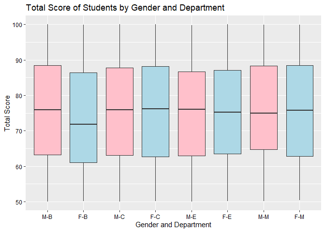

```r
ggplot(Data, aes(x = interaction(Gender, Department), y = Total_Score,
       fill = interaction(Gender, Department))) +
  geom_boxplot(show.legend = FALSE) +
  scale_fill_manual(values = rep(c("pink", "lightblue"), times = 4)) +
  labs(
    x = "Gender and Department",
    y = "Total Score",
    title = "Total Score of Students by Gender and Department"
  ) +
  scale_x_discrete(labels = c("M-B", "F-B", "M-C", "F-C", "M-E", "F-E", "M-M","F-M")) +
  theme(axis.text = element_text(color = "black")
  )
```

```r
Model1=lm(Total_Score~Gender+Department+Gender:Department, data = Data)
summary.aov(Model1)
```

```
##                     Df  Sum Sq Mean Sq F value Pr(>F)
## Gender               1      99   99.48   0.480  0.489
## Department           3     658  219.47   1.059  0.365
## Gender:Department    3     828  275.90   1.331  0.262
## Residuals         4992 1034999  207.33
```

*Model*

$y_{i,j,k}(Total \quad Score) = \mu (Overall \quad Mean) + \epsilon_{i,j,k}(Error \quad Term)$

**Test the effect of family income level, parent income level and their interaction on total score.**

$H_0:$ The mean total score is the same for all the income level.  
$H_1:$ The mean total score is different for at least one pair.

$H_0:$ The mean total score is the same for all education level.  
$H_1:$ The mean total score is different for at least one pair.

$H_0:$ There is no interaction effect of family income level and parent education level.  
$H_1:$ There is interaction effect of family income level and parent education level.

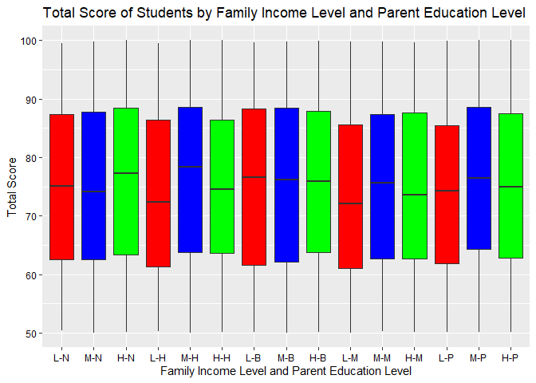

```r
ggplot(Data, aes(x = interaction(Family_Income_Level, Parent_Education_Level), y = Total_Score,
       fill = interaction(Family_Income_Level, Parent_Education_Level))) +
  geom_boxplot(show.legend = FALSE) +
  scale_fill_manual(values = rep(c("red", "blue","green"), times = 5)) +
  labs(
    x = "Family Income Level and Parent Education Level",
    y = "Total Score",
    title = "Total Score of Students by Family Income Level and Parent Education Level"
  ) +
  scale_x_discrete(labels = c("L-N", "M-N","H-N", "L-H", "M-H","H-H","L-B", "M-B","H-B", "L-M","M-M", "H-M", "L-P","M-P","H-P")) +
  theme(axis.text = element_text(color = "black")
  )
```

```r
Model2=lm(Total_Score~Family_Income_Level+Parent_Education_Level+Family_Income_Level:Parent_Education_Level, data = Data)
summary.aov(Model2)
```

```
##                                              Df  Sum Sq Mean Sq F value Pr(>F)
## Family_Income_Level                           2     892   446.1   2.151  0.116
## Parent_Education_Level                        4     464   116.1   0.560  0.692
## Family_Income_Level:Parent_Education_Level    8    1402   175.2   0.845  0.563
## Residuals                                  4985 1033826   207.4
```

*Model*

$y_{i,j,k}(Total \quad Score) = \mu (Overall \quad Mean) + \epsilon_{i,j,k}(Error \quad Term)$

**Testing for performance across stress levels at 5% significant level.**

$H_0:$ The mean total score is the same for students in the 10 different stress levels.

$H_1:$ The mean total score is different for students in the 10 different stress levels.

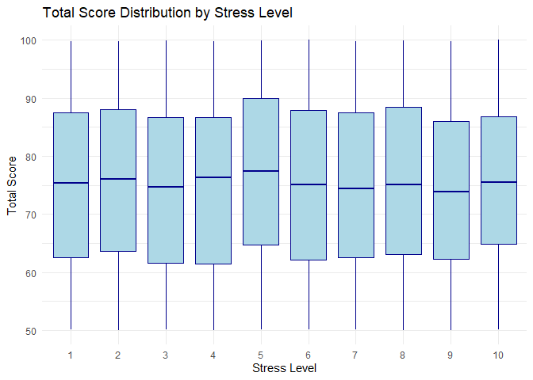

```r
Data$Stress_Level=as.factor(Data$Stress_Level)

ggplot(Data, aes(x = Stress_Level, y = Total_Score)) +
  geom_boxplot(fill = "lightblue", color = "darkblue") +
  labs(title = "Total Score Distribution by Stress Level",
       x = "Stress Level",
       y = "Total Score") +
  theme_minimal()
```

```r
Model3=lm(Total_Score~Stress_Level, data = Data)
summary.aov(Model3)
```

```
##                Df  Sum Sq Mean Sq F value Pr(>F)
## Stress_Level    9    2236   248.4   1.198  0.291
## Residuals    4990 1034349   207.3
```

We fail to reject the null hypothesis, hence there is no effect of stress level on student’s total score.

*Model*

$y_{i,j}(Total \quad Score) = \mu (Overall \quad Mean) + \epsilon_{i,j}(Error \quad Term)$

**Testing for whether attendance percent is same in the various grades at 5% significant level.**

$H_0:$ The mean attendance percent is the same in the grade types.

$H_1:$ The mean attendance percent is different in at least one pair.

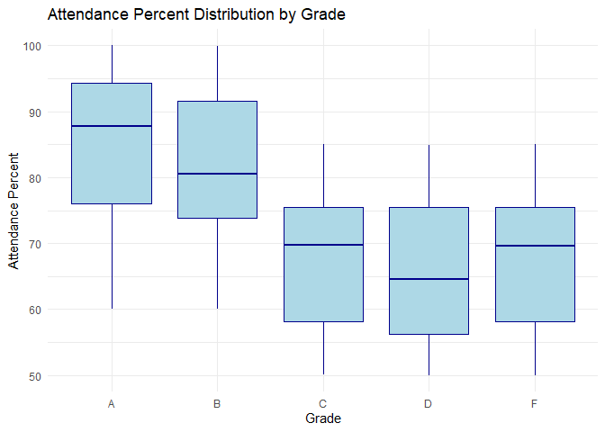

```r
Data$Grade=as.factor(Data$Grade)

ggplot(Data, aes(x = Grade, y = Attendance_Percent)) +
  geom_boxplot(fill = "lightblue", color = "darkblue") +
  labs(title = "Attendance Percent Distribution by Grade",
       x = "Grade",
       y = "Attendance Percent") +
  theme_minimal()
```

```r
Model4=lm(Attendance_Percent~Grade, data = Data)
summary.aov(Model4)
```

```
##               Df Sum Sq Mean Sq F value Pr(>F)
## Grade          4 364249   91062   809.7 <2e-16 ***
## Residuals   4995 561792     112
## ---
## Signif. codes:  0 '***' 0.001 '**' 0.01 '*' 0.05 '.' 0.1 ' ' 1
```

We reject the null hypothesis, which means that the attendance percent a student get in their score to obtain a grade is different. This indicates that some students may have not attended some class.

*Model*

$y_{i,j}(Attendance \quad Percent) = \mu (Overall \quad Mean) + \alpha_i(Grade Effect) \epsilon_{i,j}(Error \quad Term)$

## Regression

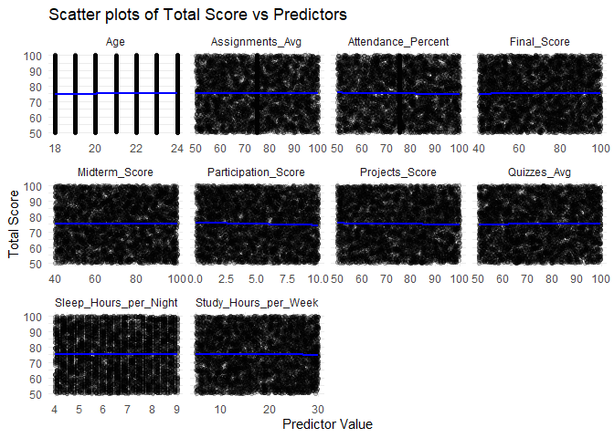

```r
df_long = Data %>%
  pivot_longer(cols = c(Sleep_Hours_per_Night,Study_Hours_per_Week,Projects_Score, Quizzes_Avg, Assignments_Avg,Final_Score,Midterm_Score,Attendance_Percent,Age,Participation_Score), names_to = "Predictor", values_to = "Value")

#Scatter Plot

ggplot(df_long, aes(x = Value, y = Total_Score)) +
  geom_point(alpha = 0.2) +
  geom_smooth(method = "lm", se = FALSE, color = "blue") +
  facet_wrap(~ Predictor, scales = "free_x") +
  theme_minimal()+
  labs(title = "Scatter plots of Total Score vs Predictors",
       x = "Predictor Value", y = "Total Score")
```

The plot above is the scatter plot of the total score of students and age, assignment average, attendance percent, midterm score, participation score, projects score, quizzes average, sleep hours per night, study hours per week and final score. From the plot, there is no linear relationship between these variables and total score.

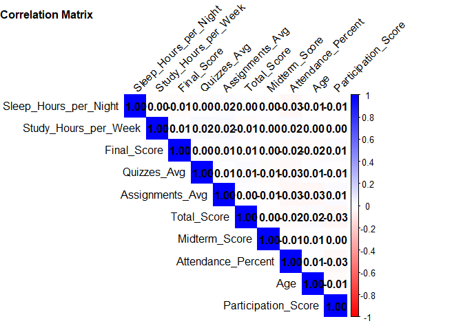

```r
#Correlation Plot
cor_matrix = cor(Data[,c("Sleep_Hours_per_Night","Study_Hours_per_Week","Final_Score", "Quizzes_Avg", "Assignments_Avg","Total_Score","Midterm_Score","Attendance_Percent","Age","Participation_Score")], use = "complete.obs")

corrplot(cor_matrix, method = "color", type = "upper",
         addCoef.col = "black",
         tl.col = "black", tl.srt = 45,
         col = colorRampPalette(c("red", "white", "blue"))(200))

mtext("Correlation Matrix", side = 3, adj = 0, line = 2.5, font = 2)
```

The correlation plot indicates that there is neither moderate nor strong correlation between the variables.

**Multiple Linear Regression**

```r
#Encoding of variables
Data$Grade=factor(Data$Grade,  levels = c("A","B","C","D","F"), ordered = TRUE )
Data$Stress_Level=factor(Data$Stress_Level, levels = 1:10, ordered = TRUE)
Data$Family_Income_Level=factor(Data$Family_Income_Level, levels = c("Low", "Medium","High"), ordered= TRUE)
Data$Gender=as.factor(Data$Gender)
Data$Parent_Education_Level=factor(Data$Parent_Education_Level,  levels = c("None","High School","Bachelor's","Master's","PhD"), ordered = TRUE )
Data$Internet_Access=as.factor(Data$Internet_Access)
Data$Extracurricular_Activities=factor(Data$Extracurricular_Activities)
```

```r
#Regression on Student Performance
Reg_model1=lm(Total_Score~Age+Gender+Quizzes_Avg+Projects_Score+Participation_Score+Attendance_Percent+ Assignments_Avg+Sleep_Hours_per_Night+Midterm_Score+Final_Score+Study_Hours_per_Week+Stress_Level+Family_Income_Level+Extracurricular_Activities+Internet_Access+Parent_Education_Level, data=Data)

summary(Reg_model1)
```

```
##
## Call:
## lm(formula = Total_Score ~ Age + Gender + Quizzes_Avg + Projects_Score +
##     Participation_Score + Attendance_Percent + Assignments_Avg +
##     Sleep_Hours_per_Night + Midterm_Score + Final_Score + Study_Hours_per_Week +
##     Stress_Level + Family_Income_Level + Extracurricular_Activities +
##     Internet_Access + Parent_Education_Level, data = Data)
##
## Residuals:
##      Min       1Q   Median       3Q      Max
## -27.1637 -12.2631   0.1135  12.4590  26.5719
##
## Coefficients:
##                                 Estimate Std. Error t value Pr(>|t|)
## (Intercept)                   75.7009651  3.5767473  21.165   <2e-16 ***
## Age                            0.1256762  0.1025381   1.226   0.2204
## GenderMale                    -0.2700031  0.4079819  -0.662   0.5081
## Quizzes_Avg                    0.0129067  0.0140627   0.918   0.3588
## Projects_Score                -0.0187559  0.0141517  -1.325   0.1851
## Participation_Score           -0.1747521  0.0706114  -2.475   0.0134 *
## Attendance_Percent            -0.0203099  0.0150212  -1.352   0.1764
## Assignments_Avg                0.0020085  0.0149764   0.134   0.8933
## Sleep_Hours_per_Night          0.0213500  0.1405383   0.152   0.8793
## Midterm_Score                 -0.0003178  0.0118542  -0.027   0.9786
## Final_Score                    0.0055229  0.0118295   0.467   0.6406
## Study_Hours_per_Week          -0.0269288  0.0280840  -0.959   0.3377
## Stress_Level.L                 0.1862510  0.6471692   0.288   0.7735
## Stress_Level.Q                 0.0703962  0.6498500   0.108   0.9137
## Stress_Level.C                 0.1759766  0.6439074   0.273   0.7846
## Stress_Level^4                 1.0959327  0.6476479   1.692   0.0907 .
## Stress_Level^5                 0.2986959  0.6457979   0.463   0.6437
## Stress_Level^6                -0.7551601  0.6438687  -1.173   0.2409
## Stress_Level^7                 1.2776918  0.6415323   1.992   0.0465 *
## Stress_Level^8                 0.3914649  0.6394568   0.612   0.5404
## Stress_Level^9                -0.6971630  0.6484591  -1.075   0.2824
## Family_Income_Level.L         -0.7801532  0.3901731  -2.000   0.0456 *
## Family_Income_Level.Q         -0.1996071  0.3482002  -0.573   0.5665
## Extracurricular_ActivitiesYes  0.1886140  0.4446462   0.424   0.6714
## Internet_AccessYes            -0.6640879  0.6710561  -0.990   0.3224
## Parent_Education_Level.L      -0.1730334  0.4543691  -0.381   0.7034
## Parent_Education_Level.Q       0.1568207  0.4546292   0.345   0.7302
## Parent_Education_Level.C       0.3207317  0.4586353   0.699   0.4844
## Parent_Education_Level^4       0.5278257  0.4575240   1.154   0.2487
## ---
## Signif. codes:  0 '***' 0.001 '**' 0.01 '*' 0.05 '.' 0.1 ' ' 1
##
## Residual standard error: 14.4 on 4971 degrees of freedom
## Multiple R-squared:  0.006276,   Adjusted R-squared:  0.0006788
## F-statistic: 1.121 on 28 and 4971 DF,  p-value: 0.3005
```

```r
#stepwise_model
stepwise_model1 = step(Reg_model1, direction = "backward", trace = FALSE)
summary(stepwise_model1)
```

```
##
## Call:
## lm(formula = Total_Score ~ Participation_Score + Family_Income_Level,
##     data = Data)
##
## Residuals:
##      Min       1Q   Median       3Q      Max
## -26.0881 -12.3485   0.0766  12.5391  25.8640
##
## Coefficients:
##                       Estimate Std. Error t value Pr(>|t|)
## (Intercept)           75.86445    0.40891 185.527   <2e-16 ***
## Participation_Score   -0.17431    0.07044  -2.475   0.0134 *
## Family_Income_Level.L -0.82685    0.38915  -2.125   0.0337 *
## Family_Income_Level.Q -0.20845    0.34708  -0.601   0.5481
## ---
## Signif. codes:  0 '***' 0.001 '**' 0.01 '*' 0.05 '.' 0.1 ' ' 1
##
## Residual standard error: 14.39 on 4996 degrees of freedom
## Multiple R-squared:  0.002084,   Adjusted R-squared:  0.001485
## F-statistic: 3.477 on 3 and 4996 DF,  p-value: 0.0153
```

The adjusted $R^2$ of the stepwise model is greater than the original hence the stepwise model chosen.

*Model 1*

*Total Score = 75.86 - 0.17 $\times$ Participation Score - 0.83 $\times$ Family Income Level.L.- 0.21 $\times$ Family Income Level.Q*

In this model, the Total Score a student receives is slightly influenced by their participation and family income level. On average, students who participate more tend to have slightly lower scores, each additional point in participation is linked to a small drop in their Total Score. Similarly, as family income increases, there’s a slight downward trend in scores, suggesting that students from higher-income families tend to score a bit lower. There’s also a small curve in the income effect, but it’s not strong enough to be meaningful. Overall, these effects are statistically noticeable but quite small.

A p-value of 0.0153 indicates that there is a statistically significant but weak explanatory power, with a low probability (1.53%) that this result is due to random chance. The model has adjusted R squared of 0.1485% indicating a very poor model. 0.2% of variability in total score is explained by the model leaving 99.8% unexplained. The model accounts for a very small portion of the changes observed in the outcome variable.

**Regression Diagnosis on Model 1**

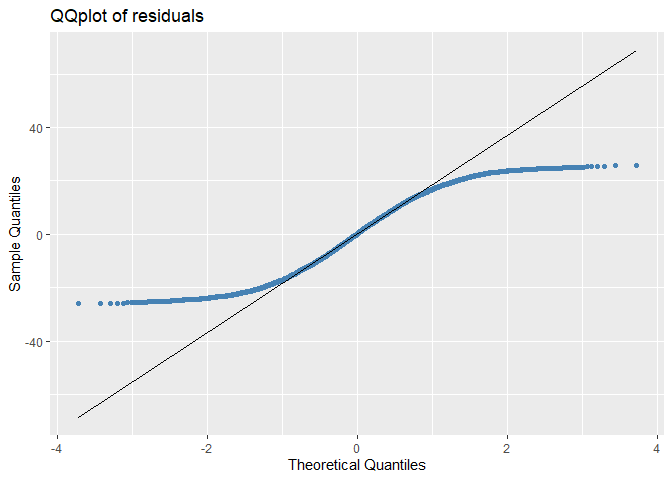

```r
#QQPlot

ggplot() +  aes(sample = residuals(stepwise_model1)) +
  stat_qq(color = "steelblue") + stat_qq_line(color = "black") +
  labs(x = "Theoretical Quantiles", y = "Sample Quantiles",
       title = "QQplot of residuals")
```

The plot is a clear indication that the residuals are not normally distributed. The points do not lie on the line.

$H_0:$ The residuals are normally distributed

$H_1:$ The residuals are not normally distributed

```r
#Normality Test
Model_Residual=resid(stepwise_model1)
shapiro.test(Model_Residual)
```

```
##
##  Shapiro-Wilk normality test
##
## data:  Model_Residual
## W = 0.95635, p-value < 2.2e-16
```

A small p-value means that we reject the null hypothesis, hence the residuals are not normally distributed.

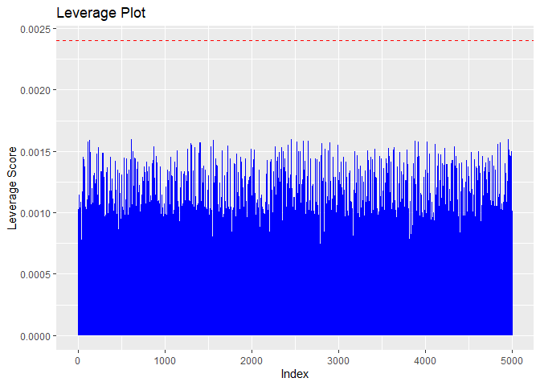

```r
#Influential Measure

lev_scores = hatvalues(stepwise_model1)
ggplot() + aes(x = seq_along(lev_scores), y = lev_scores) +
  geom_segment(aes(xend = seq_along(lev_scores), yend = 0), color = "blue") +
  geom_hline(yintercept = 3 * mean(lev_scores), linetype = "dashed", color = "red") +
  labs(x = "Index",y = "Leverage Score", title = "Leverage Plot")
```

From the leverage plot using a cutoff of 3 times mean leverage scores, there is no point that has influence on the model.

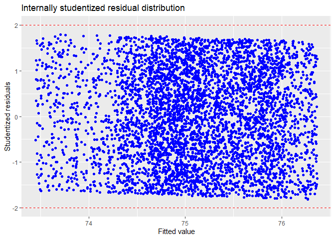

```r
#Outlier Detection

ggplot() + aes(x = fitted(stepwise_model1), y = rstandard(stepwise_model1)) + geom_point(color = 'blue') +
  geom_hline(yintercept = c(-2, 2), color = "red", linetype = "dashed") +
  labs(x = "Fitted value",y = "Studentized residuals", title = "Internally studentized residual distribution")
```

```r
outlierTest(stepwise_model1)
```

```
## No Studentized residuals with Bonferroni p < 0.05
## Largest |rstudent|:
##      rstudent unadjusted p-value Bonferroni p
## 317 -1.814335           0.069686           NA
```

From the plot, no residual point is seen above the top cutoff or below the down cutoff hence no outlier detected in the residual.Again, from the outlier test, after applying the Bonferroni correction for multiple comparisons, none of the observations have residuals that are statistically significant outliers at the 0.05 level. The observation with the largest absolute Studentized residual is identified (in this case, observation 317 with a value of -1.814335). The unadjusted p-value for this residual is 0.069686, which is above the typical significance threshold of 0.05. Therefore, even before adjustment, this observation isn’t considered a significant outlier.

$H_0$: Homoskedasticity (constant variance of residuals).

$H_1$: Heteroskedasticity (non-constant variance of the residuals).

```r
# Homoskedasticity Check

ncvTest(stepwise_model1)
```

```
## Non-constant Variance Score Test
## Variance formula: ~ fitted.values
## Chisquare = 0.07187702, Df = 1, p = 0.78862
```

There is a bigger p-value as compared to the significant level hence the null hypothesis ($H_0$) is failed to be rejected indicating constant variance of residuals in the model.

```r
vif(stepwise_model1)
```

```
##                         GVIF Df GVIF^(1/(2*Df))
## Participation_Score 1.000727  1        1.000363
## Family_Income_Level 1.000727  2        1.000182
```

The output shows both Generalized Variance Inflation Factor(GVIF) and adjusted GVIF values of approximately 1, suggesting a negligible multicollinearity.

**Logistic Regression on Internet Access Classification**  
A regression to classify a student to whether they have access to internet at home or not.

```r
#Logistics Regression
Data$Internet_Access_at_Home = ifelse(Data$Internet_Access_at_Home == "Yes", 1, 0)

Data$Grade=factor(Data$Grade,  levels = c("A","B","C","D","F"), ordered = TRUE )
Data$Stress_Level=factor(Data$Stress_Level, levels = 1:10, ordered = TRUE)
Data$Family_Income_Level=factor(Data$Family_Income_Level, levels = c("Low", "Medium","High"), ordered= TRUE)
Data$Gender=factor(Data$Gender)
Data$Parent_Education_Level=factor(Data$Parent_Education_Level,  levels = c("None","High School","Bachelor's","Master's","PhD"), ordered = TRUE )
Data$Extracurricular_Activities=factor(Data$Extracurricular_Activities)



# Fit logistic model
Logistic_Model = glm(
  Internet_Access_at_Home ~ Sleep_Hours_per_Night + Participation_Score +
  Parent_Education_Level + Family_Income_Level + Extracurricular_Activities +
  Stress_Level + Projects_Score + Gender + Age + Study_Hours_per_Week +
  Total_Score + Attendance_Percent + Quizzes_Avg + Assignments_Avg +
  Midterm_Score + Final_Score,
  data = Data,
  family = "binomial"
)

# Predict probabilities
predicted_probs = predict(Logistic_Model, type = "response")

# ROC analysis
roc_object = roc(
  Data$Internet_Access_at_Home,
  predicted_probs,
  levels = c(0, 1),
  direction = "<",
  quiet = TRUE
)

#Threshold
youden_cutoff = coords(roc_object, "best", ret = "threshold", best.method = "youden")
topleft_cutoff = coords(roc_object, "best", ret = "threshold", best.method = "closest.topleft")
cat("Youden cutoff:", youden_cutoff$threshold, "\nTop-left cutoff:", topleft_cutoff$threshold)
```

```
## Youden cutoff: 0.8959947
## Top-left cutoff: 0.8959947
```

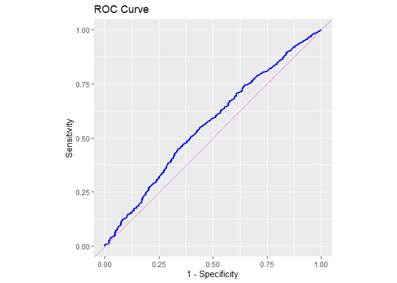

```r
optimal_threshold = youden_cutoff$threshold
predicted_class = ifelse(predicted_probs >= optimal_threshold, 1, 0)


ggplot() + aes(x = 1-roc_object$specificities, y = roc_object$sensitivities) +
  geom_line(color = "blue", linewidth = 1) + coord_equal() +
  geom_abline(intercept = 0, slope = 1, color = "orchid") +
  labs(x = "1 - Specificity", y = "Sensitivity", title = "ROC Curve")
```

```r
conf_matrix = table(Predicted = predicted_class, Actual = Data$Internet_Access_at_Home)
rownames(conf_matrix) = c("Predicted: 0", "Predicted: 1")
colnames(conf_matrix) = c("Actual: 0", "Actual: 1")
conf_matrix
```

```
##               Actual
## Predicted      Actual: 0 Actual: 1
##   Predicted: 0       289      2022
##   Predicted: 1       226      2463
```

```r
# Accuracy
mean(predicted_class == Data$Internet_Access_at_Home)
```

```
## [1] 0.5504
```

## Key Findings

From the analysis,

## Limitations

1. There is no linear relationship existing between variables, hence performance can not be properly model using multiple linear regression for performance prediction.
2. Finding the relation between variables in order to perform regression and ANOVA.

## Recommendations

1. In order to control psychological problems in the future, schools and instructors should think about offering individualized support, which would encourage under-engaged students to get more involved while also aiding extremely stressed students with coping mechanisms although stress level has no effect on performance.
2. The sample size should be increased in order to determine hidden relationship.
3. There might be a non linear relationship existing among the variable, further analysis is required for a non linear regression model.
4. Although I tried a random forest model, its performance was poor with very low accuracy, so it was not included in the report. However, other machine learning models could still be applied to this data.

**Data source: kaggle.com**